# Introduction to ggtaichi

Youzhi Yu University of Chicago

## Why taichi?

A heat map drawn with `ggplot2::geom_tile()` carries three dimensions of information: the `x` position, the `y` position, and a single value mapped to fill. That is plenty when there is one number per cell, but it forces you to *facet* (or to draw two separate maps) the moment you want to compare two data sources on the same footing.

`ggtaichi` removes that limitation by replacing each cell with a **taichi** (yin-yang) diagram. The symbol is a circle split by an S-curve into two interlocking “fish”:

- the **yang** (light) fish is shaded by one data source, and
- the **yin** (dark) fish is shaded by the other.

Because both fish live in the same cell, a single `geom_taichi()` layer encodes **four** dimensions at once: `x`, `y`, `yin`, and `yang`. The two sources keep their own color scales and legends, so they can be read independently while still being compared side by side. By default there are no decorative eyes or markers, so every drop of ink on the plot is mapped to data; and when you do switch the classic eyes on (`eyes = TRUE`, new in v0.2.0), they can carry data too, taking a single glyph up to **six** dimensions.

```r
library(ggtaichi)
library(ggplot2)
```

## Reading a single symbol

It is worth zooming in on one cell to see the anatomy of the glyph. The yang fish (its bulb at the bottom) carries one source; the yin fish (its bulb at the top) carries the other. Each half is filled by its own gradient, so a lighter or darker shade is a smaller or larger value.

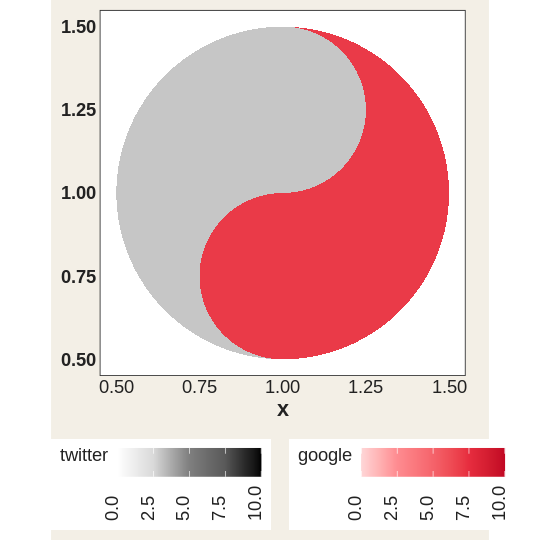

```r
one <- data.frame(x = 1, y = 1, google = 7, twitter = 3)

ggplot(one, aes(x, y)) +
  geom_taichi(yin = twitter, yang = google, limits = c(0, 10)) +
  coord_fixed() +
  theme_taichi()
```

Here the yang (red) fish reads `7` and the yin (grey) fish reads `3`; the deeper the ink, the larger the number. A single cell has no range of its own to shade against, so `limits = c(0, 10)` gives both scales one: without it, each fill scale would be trained on one value and draw it at the middle of its ramp.

## The example data

`ggtaichi` ships with the same data sets used by its foundational package `ggDoubleHeat`. `pitts_tg` records the 30-week COVID-related Google and Twitter incidence rates for 9 categories in the Pittsburgh Metropolitan Statistical Area (MSA).

```r
head(pitts_tg)
```

```
#> # A tibble: 6 × 6
#>   msa         week week_start category          Twitter Google
#>   <chr>      <int> <date>     <chr>               <dbl>  <dbl>
#> 1 Pittsburgh     1 2020-06-01 Covid              0.965  0.681
#> 2 Pittsburgh     1 2020-06-01 General Virus      0.538  0.0982
#> 3 Pittsburgh     1 2020-06-01 Masks              0.466  0.117
#> 4 Pittsburgh     1 2020-06-01 Sanitizing         0.0561 0.127
#> 5 Pittsburgh     1 2020-06-01 Social Distancing  0.294  0.0386
#> 6 Pittsburgh     1 2020-06-01 Symptoms           0.0457 0.0770
```

`states_tg` is the larger sibling, repeating the same measurements across four states, and `pitts_emojis` holds the most popular weekly emoji per category. Since v0.2.0 the package also bundles `cafes_tg`, a small *synthetic* espresso-vs-matcha dataset whose two columns share the same units, which makes it handy for the shared-scale features shown later. See `?pitts_tg`, `?states_tg`, `?pitts_emojis`, and `?cafes_tg` for the full descriptions.

## A first taichi grid

The two value columns are passed to the `yin` and `yang` arguments. Everything else (the `x`/`y` mapping, faceting, titles) is plain `ggplot2`. The legend titles default to the column names you supplied (`Twitter` and `Google` here).

[figure not shown]

```r
ggplot(pitts_tg, aes(x = week, y = category)) +
  geom_taichi(yin = Twitter, yang = Google) +
  theme_taichi() +
  ggtitle("Pittsburgh Google & Twitter Incidence Rate (%)")
```

Each symbol stays round regardless of the panel’s aspect ratio, so you do **not** need `coord_fixed()`. The shape is sized in square units, like the radius of a `grid::circleGrob()`.

## Fewer cells, bigger glyphs

Thirty weeks across nine categories is a lot of ink in one panel. When the goal is to *read* individual symbols rather than scan an overall texture, subset the data: fewer cells means each taichi is drawn larger.

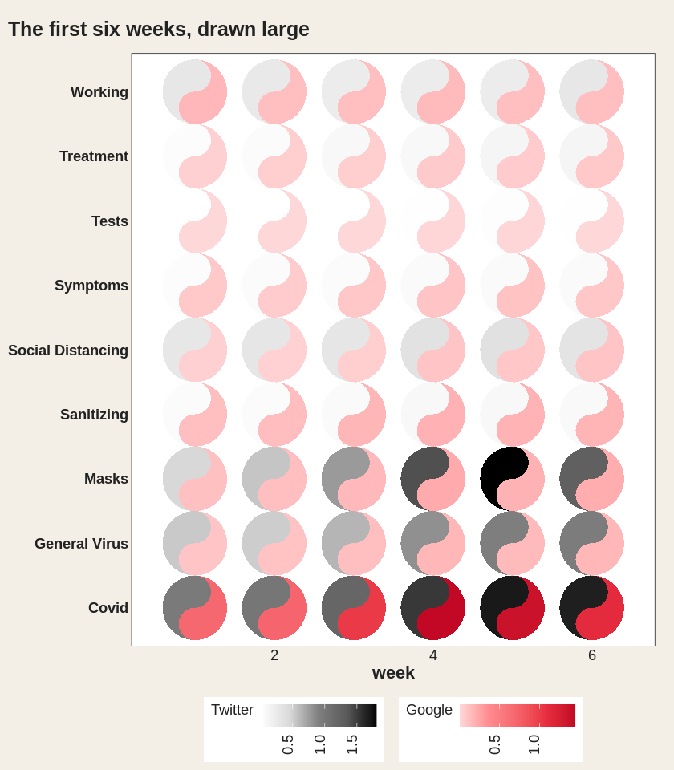

```r
pitts_small <- subset(pitts_tg, week <= 6)

ggplot(pitts_small, aes(x = week, y = category)) +
  geom_taichi(yin = Twitter, yang = Google) +
  theme_taichi() +
  ggtitle("The first six weeks, drawn large")
```

## Which source should be yin?

`yin` defaults to a grey (luminance) ramp and `yang` to a red ramp, echoing the “ink and seal” look of a classic taichi. The choice is yours, but a useful rule of thumb is to put the source you want to read as *intensity* on `yin` (the eye reads darkness quickly) and the source you want to read as *warmth* on `yang`.

## Customizing the color scales

Each fish gets its own scale. `yang_colors` and `yin_colors` accept any color vector (usually hex codes), and `yang_name` / `yin_name` relabel the legends. Any extra argument in `...` is forwarded to *both* auto-built fill scales, so you can, for example, set common `limits` so the two legends share a range, or pass an `na.value`. When the two fish need *different* scale options, or an entirely different scale type, hand a scale object or constructor to `yin_scale` / `yang_scale` and it replaces the automatic one.

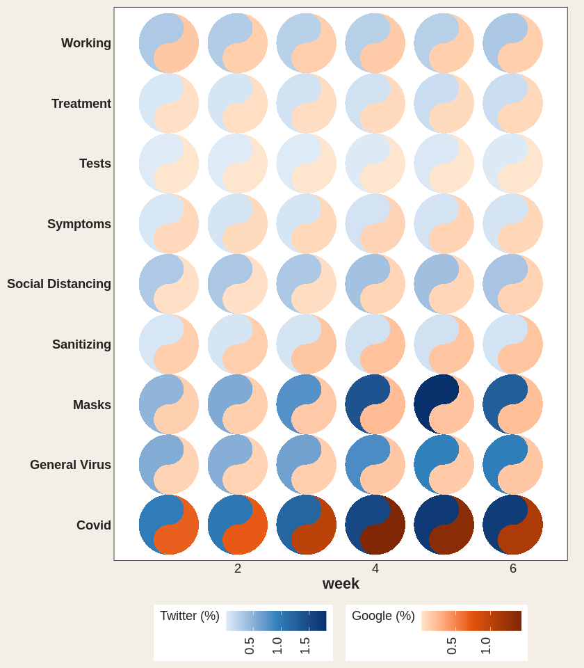

```r
ggplot(pitts_small, aes(x = week, y = category)) +
  geom_taichi(
    yin = Twitter,  yin_name = "Twitter (%)",
    yin_colors = c("#deebf7", "#3182bd", "#08306b"),
    yang = Google, yang_name = "Google (%)",
    yang_colors = c("#fee6ce", "#e6550d", "#7f2704")
  ) +
  theme_taichi()
```

## Removing the panel padding

`ggplot2` leaves a margin around discrete and continuous scales, which can make a taichi grid look like it is floating. `remove_padding()` trims it. As of v0.2.0 it detects each axis’s scale type by itself, and you can still spell it out with `"c"` (continuous) / `"d"` (discrete) when you want to override the detection.

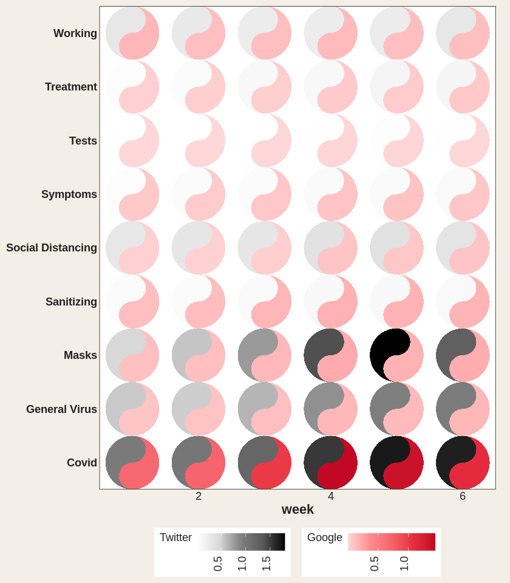

```r
ggplot(pitts_small, aes(x = week, y = category)) +
  geom_taichi(yin = Twitter, yang = Google) +
  remove_padding() +
  theme_taichi()
```

## Comparing places with facets

Because `geom_taichi()` is an ordinary layer, faceting works out of the box. The `states_tg` data set carries the same measurements across four states; pairing two of them over a few weeks keeps every glyph large and legible.

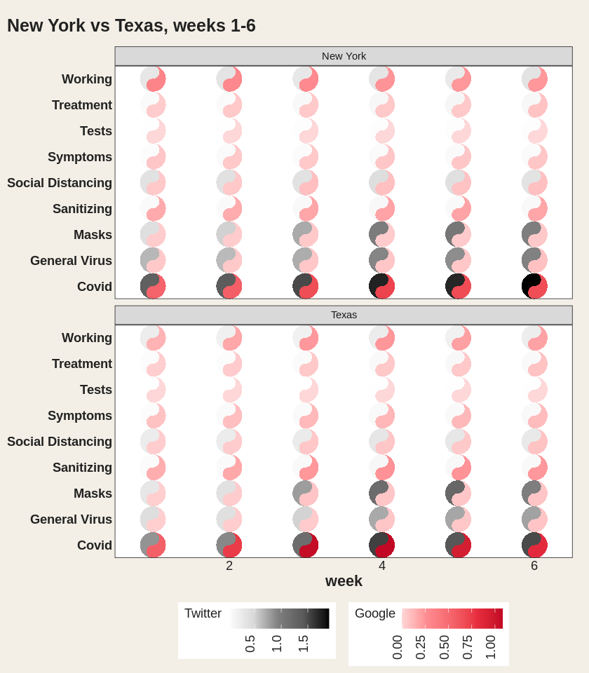

```r
two_states <- subset(states_tg, state %in% c("New York", "Texas") & week <= 6)

ggplot(two_states, aes(x = week, y = category)) +
  geom_taichi(yin = Twitter, yang = Google) +
  facet_wrap(~ state, ncol = 1) +
  remove_padding(x = "c", y = "d") +
  theme_taichi() +
  ggtitle("New York vs Texas, weeks 1-6")
```

## Theming

`theme_taichi()` is a light, off-white companion theme that bottoms the legends, drops the panel grid and ticks, and emphasizes the axis labels. It is a normal `ggplot2` theme, so you can override any element afterwards, or skip it entirely and bring your own.

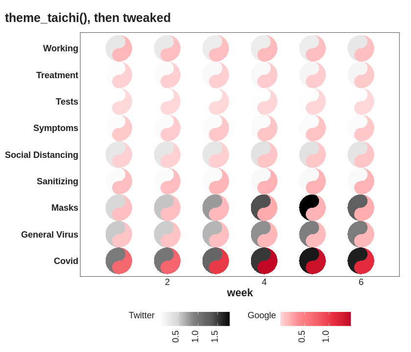

```r
ggplot(pitts_small, aes(x = week, y = category)) +
  geom_taichi(yin = Twitter, yang = Google) +
  theme_taichi() +
  theme(plot.background = element_rect(fill = "white")) +
  ggtitle("theme_taichi(), then tweaked")
```

## The glyph’s other channels

### Rotation

The `angle` argument rotates each glyph by the given number of degrees. It can be a constant (same angle for every cell) or a column name (one angle per cell), encoding a directional or temporal variable as orientation.

[figure not shown]

```r
one_rot <- data.frame(
  x = c(1, 2, 1, 2),
  y = c(2, 2, 1, 1),
  yin = c(3, 5, 7, 9),
  yang = c(9, 7, 5, 3),
  rot = c(0, 45, 90, 180)
)

ggplot(one_rot, aes(x, y)) +
  geom_taichi(yin = yin, yang = yang, angle = rot,
              limits = c(0, 10)) +
  coord_fixed() +
  theme_taichi()
```

### Data-driven eyes

Setting `eyes = TRUE` draws the classic taichi dots, each sitting in its own fish’s head: the yin eye in the top bulb, the yang eye in the bottom one. With the default white and black dots the glyph looks exactly like the traditional symbol.

[figure not shown]

```r
one_eye <- data.frame(
  x = c(1, 2, 1, 2),
  y = c(2, 2, 1, 1),
  yin = c(3, 5, 7, 9),
  yang = c(9, 7, 5, 3)
)

ggplot(one_eye, aes(x, y)) +
  geom_taichi(yin = yin, yang = yang, eyes = TRUE,
              limits = c(0, 10)) +  # shared limits keep the palest fish visible
  coord_fixed() +
  theme_taichi()
```

The eyes are not just decoration: `yin_eye_size`, `yang_eye_size`, `yin_eye_colour`, and `yang_eye_colour` all accept either a constant *or an unquoted column name*, so the two dots can encode up to two further variables: a **fifth and sixth dimension** on top of `x`, `y`, and the two fills. A mapped size column is rescaled to eye radii between 5% and 30% of the glyph radius (values already between 0 and 0.5 are used as exact proportions, and an `NA` suppresses the eye for that cell).

[figure not shown]

```r
one_eye$reach   <- c(10, 40, 25, 5)   # drives the yin eye
one_eye$quality <- c(2, 1, 4, 8)      # drives the yang eye

ggplot(one_eye, aes(x, y)) +
  geom_taichi(yin = yin, yang = yang,
              eyes = TRUE,
              yin_eye_size = reach,
              yang_eye_size = quality,
              limits = c(0, 10)) +
  coord_fixed() +
  theme_taichi()
```

### Categorical fills

`geom_taichi()` now automatically detects whether the `yin` / `yang` columns are numeric or discrete (factor / character / logical) and picks the appropriate scale; computed expressions such as `factor(week)` work too. With the default palettes the discrete colors are sampled from the ramp skipping its palest end, so every category stays visible.

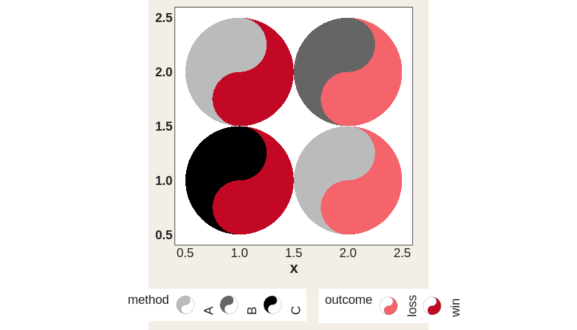

```r
disc <- data.frame(
  x = c(1, 2, 1, 2),
  y = c(2, 2, 1, 1),
  method = factor(c("A", "B", "C", "A")),
  outcome = factor(c("win", "loss", "win", "loss"))
)

ggplot(disc, aes(x, y)) +
  geom_taichi(yin = method, yang = outcome) +
  coord_fixed() +
  theme_taichi()
```

For full control, hand any fill scale (an object or a constructor function) to `yin_scale` / `yang_scale`; it overrides the auto-detection and the `*_colors` vectors entirely:

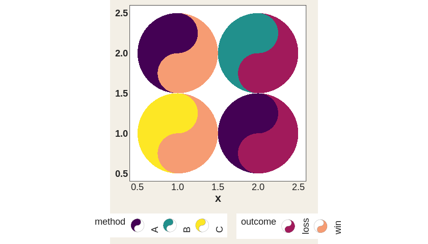

```r
ggplot(disc, aes(x, y)) +
  geom_taichi(yin = method, yang = outcome,
              yin_scale = scale_fill_viridis_d,
              yang_scale = scale_fill_viridis_d(name = "outcome", option = "rocket",
                                                begin = 0.4, end = 0.8)) +
  coord_fixed() +
  theme_taichi()
```

### Missing values

A fish whose fill value is `NA` is painted in its scale’s `na.value` colour (grey by default; pass e.g. `na.value = "transparent"` through `...` to hide it), so one missing source never suppresses the other fish. `na.rm = TRUE` additionally drops rows with missing positions, and an `NA` eye size simply skips that cell’s eye.

### Geom parameter routing

All standard geom parameters (`alpha`, `colour`, `linewidth`, `linetype`, `width`, `height`, `na.rm`, `show.legend`) are now properly accepted by `geom_taichi()` and forwarded to the underlying fish geoms. The deprecated `size` aesthetic has been replaced with `linewidth`.

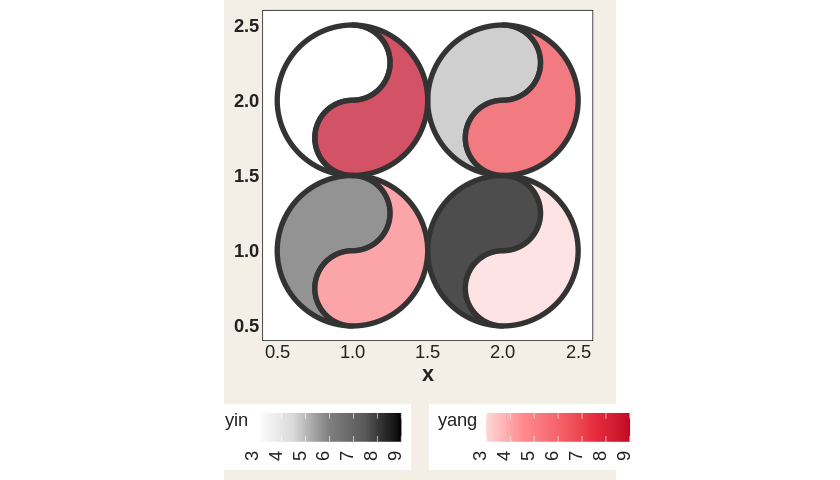

```r
one_lwd <- data.frame(
  x = c(1, 2, 1, 2),
  y = c(2, 2, 1, 1),
  yin = c(3, 5, 7, 9),
  yang = c(9, 7, 5, 3)
)

ggplot(one_lwd, aes(x, y)) +
  geom_taichi(yin = yin, yang = yang,
              alpha = 0.7, linewidth = 1.5, colour = "#333333") +
  coord_fixed() +
  theme_taichi()
```

### Shared limits and a single legend

When the two sources are measured in the same units, two separate legends are noise. `shared_limits = TRUE` aligns the limits of both fill scales (the union range of the two columns, or the union of levels for two discrete sources), so equal values carry equal ink. `shared_legend = TRUE` goes further: both fish use the yin palette and only one legend is shown. The synthetic `cafes_tg` data, espresso and matcha orders per 100 customers, is the natural demo:

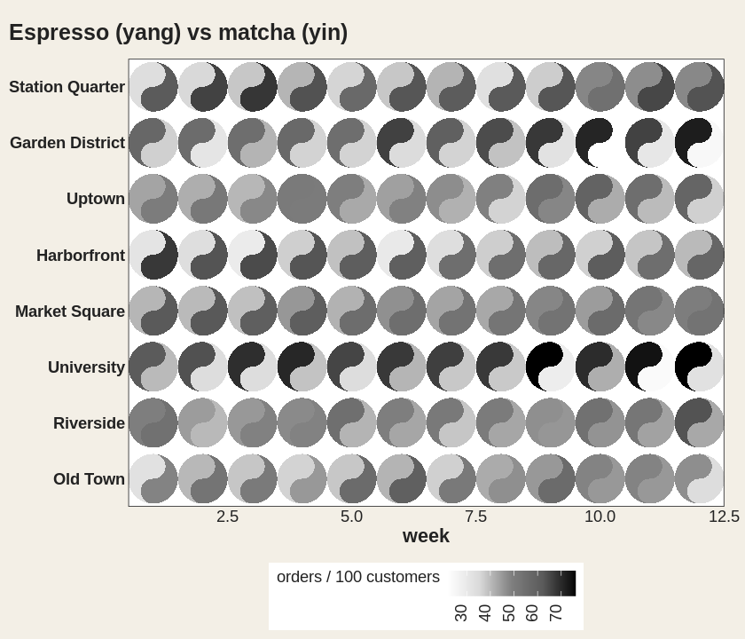

```r
ggplot(cafes_tg, aes(x = week, y = neighbourhood)) +
  geom_taichi(yin = matcha, yang = espresso,
              shared_legend = TRUE,
              yin_name = "orders / 100 customers") +
  remove_padding() +
  theme_taichi() +
  ggtitle("Espresso (yang) vs matcha (yin)")
```

For diverging data (values around 0), pass a diverging palette to both color arguments and symmetric limits through `...`, e.g. `limits = c(-5, 5)`, and both fish then hinge on the same midpoint.

### The fish geoms are exported

`geom_yin_fish()` and `geom_yang_fish()`, the layers `geom_taichi()` is built from, are now exported and documented. Reach for them when you want one fish only, or full manual control over scales and `ggnewscale::new_scale_fill()` stacking. See `?geom_yin_fish`.

### Faster rendering

All cells of a layer are now drawn as one batched polygon (and one batch of eye dots) resolved at draw time, instead of one grob stack per cell. Large grids and animation frames render several times faster, and glyphs stay perfectly round when you resize the device.

## New in v0.3.0

### How much bigger? The explicit channel

Two fish sharing one position is what the comparison literature calls a *superposition* design. Its strength is that the two sources are in the same place, so spatial patterns line up and “are these similar?” is answered at a glance. Its weakness is precise: it can say *which* is bigger, but not *by how much*. For that, the relationship has to be computed and drawn, which the same literature calls **explicit encoding**.

`explicit` does that. It takes one of four statistics: `"difference"` (`yin - yang`), `"ratio"`, `"log_ratio"`, or `"z"` (the difference of the two standardised sources, for when the two are not in the same units). `explicit_channel` then decides where in the glyph it goes.

The default is the eyes, and it is the tidiest option: the eyes already exist, they are visually subordinate to the fills, and a big eye reads as “look here”. Cells where the two sources agree exactly get **no eye at all**, so a plain glyph means agreement.

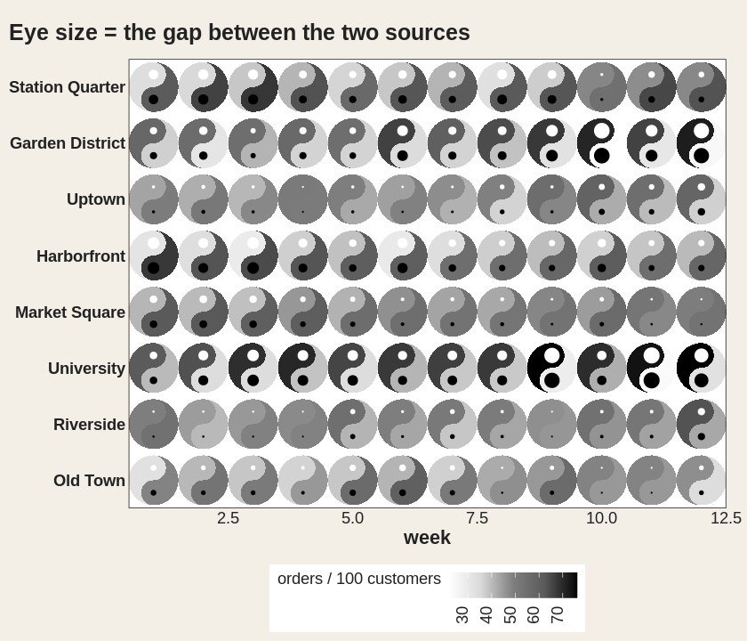

```r
ggplot(cafes_tg, aes(x = week, y = neighbourhood)) +
  geom_taichi(yin = matcha, yang = espresso,
              shared_legend = TRUE,
              yin_name = "orders / 100 customers",
              explicit = "difference") +
  remove_padding() +
  theme_taichi() +
  ggtitle("Eye size = the gap between the two sources")
```

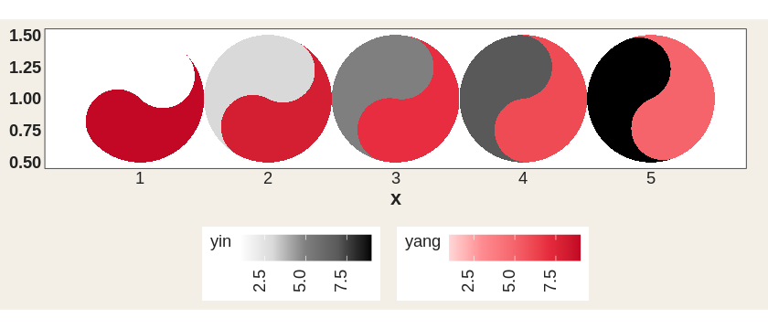

```r
tilt <- data.frame(x = 1:5, y = 1, yin = c(1, 3, 5, 7, 9), yang = 9:5)

ggplot(tilt, aes(x, y)) +
  geom_taichi(yin = yin, yang = yang, shared_limits = TRUE,
              explicit = "difference", explicit_channel = "angle") +
  coord_fixed() +
  theme_taichi()
```

The other two channels are `"border"` (outline width) and `"radius"` (glyph size, scaled by area rather than diameter, so cells where the sources agree shrink). `explicit_range` sets the output range of whichever you pick, and the statistic is rescaled across the whole layer, so facets stay comparable.

A ratio of a zero or negative value is `NA` with a warning, never `Inf`.

### The same numbers, as a table and as a heatmap

Sometimes the right answer to “by how much?” is not a glyph. `taichi_summary()` returns every statistic per cell, plus which source dominates and the cell’s rank by the size of the gap:

```r
summ <- taichi_summary(cafes_tg, yin = matcha, yang = espresso,
                       x = week, y = neighbourhood)
head(summ[order(summ$rank), ], 5)
```

```
#>     x               y  yin yang difference    ratio log_ratio        z dominant
#> 35 11      University 74.1 24.0       50.1 3.087500  1.626439 4.260819   matcha
#> 82 10 Garden District 70.9 22.2       48.7 3.193694  1.675226 4.152065   matcha
#> 33  9      University 76.1 28.4       47.7 2.679577  1.422006 4.037432   matcha
#> 84 12 Garden District 72.2 24.7       47.5 2.923077  1.547488 4.038890   matcha
#> 36 12      University 76.1 32.9       43.2 2.313070  1.209809 3.637092   matcha
#>    rank
#> 35    1
#> 82    2
#> 33    3
#> 84    4
#> 36    5
```

and `geom_taichi_diff()` draws it as a diverging heatmap, with limits symmetric about “the two sources agree”, so the mid colour really is the middle:

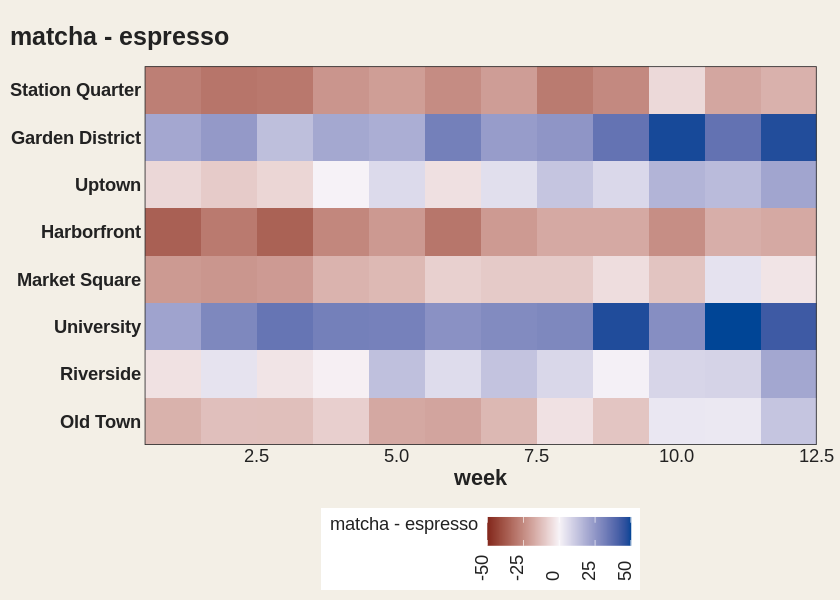

```r
ggplot(cafes_tg, aes(x = week, y = neighbourhood)) +
  geom_taichi_diff(yin = matcha, yang = espresso) +
  remove_padding() +
  theme_taichi() +
  ggtitle("matcha - espresso")
```

Use it *beside* a taichi grid rather than instead of one: the glyphs show the levels, the tiles show the gap.

### Palette pairing is a correctness problem

The whole point of the design is comparing two sources fairly, and the fills are what carries the comparison. If the two ramps do not span the same luminance range then equal values do not produce equal visual weight, and one fish appears to dominate wherever the data says the two are level. That is not a matter of taste; it decides whether the chart is telling the truth.

`taichi_check_palette()` measures it. With no arguments it measures the package’s own defaults:

```r
taichi_check_palette()
```

```
#> <ggtaichi palette check>
#>
#>   step yin            L      C   yang           L      C       dL
#>   1    #FFFFFF    100.0    0.0   #FED7D8     89.2   14.5     10.8
#>   2    #EBEBEB     93.0    0.0   #FFB2B3     79.8   30.2     13.2
#>   3    #D8D8D8     86.3    0.0   #FE8C91     70.8   46.6     15.6
#>   4    #AAAAAA     69.6    0.0   #F9787D     65.8   53.9      3.8
#>   5    #7F7F7F     53.2    0.0   #F4636B     61.0   61.4     -7.8
#>   6    #6B6B6B     45.2    0.0   #EE4B54     55.9   70.0    -10.7
#>   7    #595959     37.8    0.0   #E62C3F     50.7   78.1    -12.8
#>   8    #2D2D2D     18.5    0.0   #D41D31     45.8   77.1    -27.3
#>   9    #000000      0.0    0.0   #C10724     40.6   75.7    -40.6
#>
#>   largest luminance mismatch : 40.6 L* (tolerance 5.0)
#>   largest chroma mismatch    : 78.1
#>   measured in                : CIE Lab (L*, C*ab), CIE2000 distances
#>   how far apart the ramps stay (median distance, step for step)
#>       normal       27.2
#>       deutan       20.9
#>       protan       12.7  (much worse than normal vision)
#>       tritan       28.4
#>
#>   Verdict: FAIL
#>   the two ramps do not share a luminance trajectory, so equal
#>   values do NOT read as equal ink and one fish will appear to
#>   dominate. Consider `palette = "balanced"` or `taichi_palette_pair()`.
```

The verdict is honest: the grey yin ramp runs the full way to black while the red yang ramp stops around L* 41, a mismatch of about 41 units, so the yin fish has always looked heavier at the dark end. **The defaults have not been changed**, since every existing figure would move, but `palette = "balanced"` gives a pair built to be matched, differing only in hue:

```r
taichi_check_palette(palette = "balanced")
```

```
#> <ggtaichi palette check>
#>
#>   step yin            L      C   yang           L      C       dL
#>   1    #DEE3EC     90.1    5.0   #EDDFDE     89.9    5.1      0.2
#>   2    #C5CDDE     82.3    9.4   #E0C7C5     82.2    9.4      0.0
#>   3    #ADB8D1     74.7   13.9   #D2B1AC     74.9   13.1     -0.2
#>   4    #95A4C3     67.2   17.7   #C49A95     67.3   17.2     -0.1
#>   5    #7D91B6     59.9   21.7   #B6857E     60.1   21.0     -0.2
#>   6    #647EA9     52.4   25.9   #A76F66     52.4   25.4     -0.1
#>   7    #4A6C9D     45.1   30.4   #98594E     44.8   30.3      0.3
#>   8    #2F5A93     37.9   36.1   #894433     37.3   36.5      0.6
#>   9    #004888     30.4   41.6   #792E19     29.6   43.2      0.8
#>
#>   largest luminance mismatch : 0.8 L* (tolerance 5.0)
#>   largest chroma mismatch    : 1.5
#>   measured in                : CIE Lab (L*, C*ab), CIE2000 distances
#>   how far apart the ramps stay (median distance, step for step)
#>       normal       26.4
#>       deutan       27.7
#>       protan       22.9
#>       tritan       40.3
#>
#>   Verdict: PASS
#>   the two ramps share a luminance trajectory, so equal values
#>   read as equal ink.
```

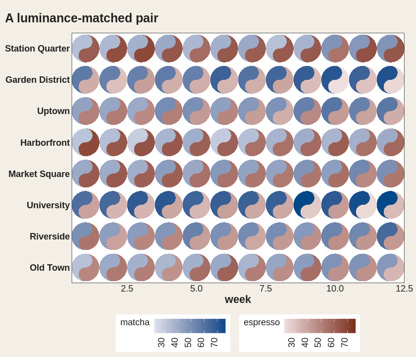

```r
ggplot(cafes_tg, aes(x = week, y = neighbourhood)) +
  geom_taichi(yin = matcha, yang = espresso,
              palette = "balanced", shared_limits = TRUE) +
  remove_padding() +
  theme_taichi() +
  ggtitle("A luminance-matched pair")
```

The other presets are `"diverging"` (both ramps reaching a shared near-white midpoint, so the two fish read as the two arms of one diverging scale), `"viridis_pair"`, `"brewer_pair"`, and `"greyscale_safe"`: a grey ramp and a hued ramp on the *same* luminance trajectory, so in colour the two fish are told apart by hue and in greyscale they collapse to the same ink, which keeps equal values equal in a black-and-white printout. `taichi_palette()` returns any of them, and `taichi_palette_pair()` builds your own from hue, luminance and chroma.

`shared_legend = TRUE` deserves a mention here too. It paints both fish with one ramp, which makes equal values equal ink *by construction*: there is no pairing left to get wrong. The cost is that the two sources are then distinguished only by their position inside the glyph: yin is the top bulb, yang the bottom. When the two sources really are directly comparable, that is usually the right trade.

### Binned fills, for grids too dense to read

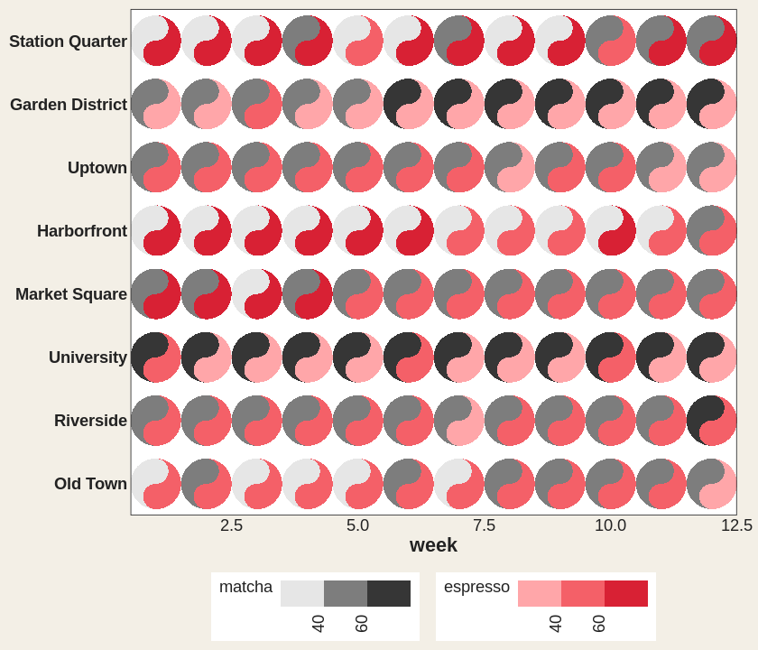

```r
ggplot(cafes_tg, aes(x = week, y = neighbourhood)) +
  geom_taichi(yin = matcha, yang = espresso,
              yin_scale  = scale_taichi_yin_binned(n.breaks = 4),
              yang_scale = scale_taichi_yang_binned(n.breaks = 4),
              shared_limits = TRUE) +
  remove_padding() +
  theme_taichi()
```

`shared_limits` now reaches into the scales you supply, so both fish share one set of breaks and equal values land in the same bin, which is the whole point of binning a two-source display. The full family is `scale_taichi_yin_c()` / `_d()` / `_binned()` / `_viridis_c()` / `_viridis_d()` and their `yang` counterparts; see `?scale_taichi`.

### Hovering for the exact values

Everything above is a way of coping with the fact that fill is an imprecise channel. Interactivity is the other way: it hands the reader the exact numbers without giving up the encoding. `interactive = TRUE` makes the fish (and their eyes) [ggiraph](https://davidgohel.github.io/ggiraph/) grobs, and `ggiraph::girafe()` turns the plot into a widget:

```r
p <- ggplot(cafes_tg, aes(x = week, y = neighbourhood)) +
  geom_taichi(yin = matcha, yang = espresso, interactive = TRUE) +
  theme_taichi()

ggiraph::girafe(ggobj = p)
```

The default tooltip carries both values, their difference, and the cell’s coordinates. `data_id_by` decides what a hover highlights, and the interesting setting is `"source"`: hovering any yin fish lights up the yin fish in *every* cell, which turns the superposition display into a single-source display for as long as the pointer rests there. That is the one thing a static superposition cannot do: it lets the reader take the comparison apart instead of doing it in their head. `tooltip`, `data_id` and `onclick` take a data column when you want to say something else.

There is a live example in the [gallery](https://pursuitofdatascience.github.io/ggtaichi/articles/gallery.html). `plotly` is not supported and will not be: `ggplotly()` cannot translate custom grobs, which is what this package draws.

### Following the theme

ggplot2 4.0 lets a theme set geom defaults through `theme(geom = element_geom(ink, paper, accent))`. ggtaichi now reads them, so the fallback fish, the outlines and both eye colours follow a dark theme instead of disappearing into it. On any light theme the result is pixel for pixel what it always was. Legend keys are small taichi symbols now as well: each fish geom’s key fills its own half and carries the layer’s own eye, and `key_glyph = "rect"` gets the old rectangles back.

## When (not) to use taichi

A taichi grid is at its best when *comparing two sources cell by cell* is the question: the interlocking fish put both numbers in one glance. A few honest caveats:

- **Dense grids become texture.** Past roughly a thousand cells you stop reading symbols and start reading fields; that is still useful for spotting bands and regime changes, but for precise lookup, subset (as done above) or facet.
- **Luminance is a coarse channel.** Small differences in a fish’s shade are hard to judge; when exact comparison matters, add shared limits (`shared_limits = TRUE`) so at least the two fish are on the same footing, and consider printing the numbers alongside.
- **The two ramps must be a fair pair.** The defaults are not: run `taichi_check_palette()` and it reports a luminance mismatch of about 41 L* units between the grey and red ramps, which means equal values do not read as equal ink. Use `palette = "balanced"` when the comparison has to be fair, and see the palette section above.
- **Colour-vision deficiency.** `taichi_check_palette()` also simulates deuteranopia, protanopia and tritanopia; the default pair loses about half its separation under protanopia. `palette = "balanced"` holds up, `palette = "greyscale_safe"` survives greyscale printing, and `scale_taichi_yin_viridis_c()` / `scale_taichi_yang_viridis_c()` are there if you prefer the viridis family.
- **One source missing?** An `NA` fish keeps its place (painted in `na.value`), so absence is visible rather than silently dropped.

## Acknowledgement

`ggtaichi` is a spinoff of the [`ggDoubleHeat`](https://CRAN.R-project.org/package=ggDoubleHeat) package, which pioneered the two-source “double” heat map and supplies the example data used throughout this vignette. `ggtaichi` takes that two-scale design and re-imagines the per-cell glyph as a taichi diagram.